# Assessment 1.1

Meral Erdogan

09 09 2021

# RMarkdown *editing*

[RMarkdown](https://rmarkdown.rstudio.com/lesson-8.html) documents provide quick, reproducible reporting from R. You write your document in markdown and embed executable R code chunks with the knitr syntax. You can update your document at any time by re-knitting the code chunks. You can then convert your document into several common formats.

#PART 1

## Loading Libraries

```r
# R libraries to use, load below libraries
library(tidyverse)
library(skimr)
library(knitr)
library(janitor)
```

```r
library(ggplot2)
library(scales)
library(lubridate)
#6 Reading data
fastfood<-read.csv('https://raw.githubusercontent.com/rfordatascience/tidytuesday/master/data/2018/2018-09-04/fastfood_calories.csv')
```

```r
#7A Displaying first 10 rows using function head
head(fastfood, 10)
```

```
##     X restaurant                                      item calories cal_fat
## 1   1  Mcdonalds          Artisan Grilled Chicken Sandwich      380      60
## 2   2  Mcdonalds            Single Bacon Smokehouse Burger      840     410
## 3   3  Mcdonalds            Double Bacon Smokehouse Burger     1130     600
## 4   4  Mcdonalds Grilled Bacon Smokehouse Chicken Sandwich      750     280
## 5   5  Mcdonalds  Crispy Bacon Smokehouse Chicken Sandwich      920     410
## 6   6  Mcdonalds                                   Big Mac      540     250
## 7   7  Mcdonalds                              Cheeseburger      300     100
## 8   8  Mcdonalds                  Classic Chicken Sandwich      510     210
## 9   9  Mcdonalds                       Double Cheeseburger      430     190
## 10 10  Mcdonalds      Double Quarter PounderÂ® with Cheese      770     400
##    total_fat sat_fat trans_fat cholesterol sodium total_carb fiber sugar
## 1          7       2       0.0          95   1110         44     3    11
## 2         45      17       1.5         130   1580         62     2    18
## 3         67      27       3.0         220   1920         63     3    18
```

[output cut: 18 more lines]

```r
#7B Displaying first 10 rows and 5 variables using function kable
kable(fastfood[1:10, 1:5], caption = "First 10 Rows and first 5 Variables of Fastfood Dataset")
```

First 10 Rows and first 5 Variables of Fastfood Dataset

| X | restaurant | item | calories | cal_fat |
| --- | --- | --- | --- | --- |
| 1 | Mcdonalds | Artisan Grilled Chicken Sandwich | 380 | 60 |
| 2 | Mcdonalds | Single Bacon Smokehouse Burger | 840 | 410 |
| 3 | Mcdonalds | Double Bacon Smokehouse Burger | 1130 | 600 |
| 4 | Mcdonalds | Grilled Bacon Smokehouse Chicken Sandwich | 750 | 280 |
| 5 | Mcdonalds | Crispy Bacon Smokehouse Chicken Sandwich | 920 | 410 |
| 6 | Mcdonalds | Big Mac | 540 | 250 |
| 7 | Mcdonalds | Cheeseburger | 300 | 100 |
| 8 | Mcdonalds | Classic Chicken Sandwich | 510 | 210 |
| 9 | Mcdonalds | Double Cheeseburger | 430 | 190 |
| 10 | Mcdonalds | Double Quarter PounderÂ® with Cheese | 770 | 400 |

```r
#8 Showing observations with more than 1000 calories by using function filter
fastfood%>%
filter(calories>1000)
```

```
##      X  restaurant                                             item calories
## 1    3   Mcdonalds                   Double Bacon Smokehouse Burger     1130
## 2   38   Mcdonalds       10 piece Buttermilk Crispy Chicken Tenders     1210
## 3   39   Mcdonalds       12 piece Buttermilk Crispy Chicken Tenders     1510
## 4   40   Mcdonalds       20 piece Buttermilk Crispy Chicken Tenders     2430
## 5   45   Mcdonalds                       40 piece Chicken McNuggets     1770
## 6   48   Mcdonalds 10 piece Sweet N' Spicy Honey BBQ Glazed Tenders     1600
## 7   99       Sonic   Super Sonic Bacon Double Cheeseburger (w/mayo)     1280
## 8  100       Sonic       Super Sonic Double Cheeseburger W/ Mustard     1120
## 9  101       Sonic       Super Sonic Double Cheeseburger W/ Ketchup     1130
## 10 102       Sonic          Super Sonic Double Cheeseburger W/ Mayo     1220
## 11 103       Sonic         Super Sonic Jalapeno Double Cheeseburger     1120
## 12 116       Sonic Garlic Parmesan Dunked Ultimate Chicken Sandwich     1350
## 13 122       Sonic        4 Piece Super Crunch Chicken Strip Dinner     1080
## 14 123       Sonic        5 Piece Super Crunch Chicken Strip Dinner     1190
```

[output cut: 72 more lines]

```r
#9 Showing observations with more than 40 in total_fat and more than 80 in total_carb by using function filter
dont_eat_this<-fastfood%>%
filter(total_fat>40 & total_carb>80)
print(dont_eat_this)
```

```
##      X  restaurant                                             item calories
## 1    5   Mcdonalds         Crispy Bacon Smokehouse Chicken Sandwich      920
## 2   40   Mcdonalds       20 piece Buttermilk Crispy Chicken Tenders     2430
## 3   45   Mcdonalds                       40 piece Chicken McNuggets     1770
## 4   48   Mcdonalds 10 piece Sweet N' Spicy Honey BBQ Glazed Tenders     1600
## 5  121       Sonic        3 Piece Super Crunch Chicken Strip Dinner      970
## 6  122       Sonic        4 Piece Super Crunch Chicken Strip Dinner     1080
## 7  123       Sonic        5 Piece Super Crunch Chicken Strip Dinner     1190
## 8  161       Arbys                     Pecan Chicken Salad Sandwich      840
## 9  176       Arbys                           Triple Decker Sandwich     1030
## 10 270 Dairy Queen    4 Piece Chicken Strip Basket w/ Country Gravy     1030
## 11 271 Dairy Queen    6 Piece Chicken Strip Basket w/ Country Gravy     1260
## 12 291 Dairy Queen                              Steak Finger Basket      910
## 13 310      Subway                        Footlong Big Hot Pastrami     1160
## 14 319      Subway         Footlong Carved Turkey & Bacon w/ Cheese     1140
```

[output cut: 48 more lines]

```r
#10 Showing observations for restaurant Mcdonalds by using function filter
fastfood%>%
filter(restaurant == "Mcdonalds")
```

```
##     X restaurant                                              item calories
## 1   1  Mcdonalds                  Artisan Grilled Chicken Sandwich      380
## 2   2  Mcdonalds                    Single Bacon Smokehouse Burger      840
## 3   3  Mcdonalds                    Double Bacon Smokehouse Burger     1130
## 4   4  Mcdonalds         Grilled Bacon Smokehouse Chicken Sandwich      750
## 5   5  Mcdonalds          Crispy Bacon Smokehouse Chicken Sandwich      920
## 6   6  Mcdonalds                                           Big Mac      540
## 7   7  Mcdonalds                                      Cheeseburger      300
## 8   8  Mcdonalds                          Classic Chicken Sandwich      510
## 9   9  Mcdonalds                               Double Cheeseburger      430
## 10 10  Mcdonalds              Double Quarter PounderÂ® with Cheese      770
## 11 11  Mcdonalds                                    Filet-O-FishÂ®      380
## 12 12  Mcdonalds                       Garlic White Cheddar Burger      620
## 13 13  Mcdonalds     Grilled Garlic White Cheddar Chicken Sandwich      530
## 14 14  Mcdonalds      Crispy Garlic White Cheddar Chicken Sandwich      700
```

[output cut: 159 more lines]

#PART 2

```r
#11 Displaying the types of variables by using function skimr
fastfood%>%
skim()
```

Data summary

| Name | Piped data |
| --- | --- |
| Number of rows | 515 |
| Number of columns | 18 |
| _______________________ |  |
| Column type frequency: |  |
| character | 3 |
| numeric | 15 |
| ________________________ |  |
| Group variables | None |

**Variable type: character**

| skim_variable | n_missing | complete_rate | min | max | empty | n_unique | whitespace |
| --- | --- | --- | --- | --- | --- | --- | --- |
| restaurant | 0 | 1 | 5 | 11 | 0 | 8 | 0 |
| item | 0 | 1 | 5 | 63 | 0 | 505 | 0 |
| salad | 0 | 1 | 5 | 5 | 0 | 1 | 0 |

**Variable type: numeric**

| skim_variable | n_missing | complete_rate | mean | sd | p0 | p25 | p50 | p75 | p100 | hist |
| --- | --- | --- | --- | --- | --- | --- | --- | --- | --- | --- |
| X | 0 | 1.00 | 258.00 | 148.81 | 1 | 129.5 | 258.0 | 386.5 | 515 | ▇▇▇▇▇ |
| calories | 0 | 1.00 | 530.91 | 282.44 | 20 | 330.0 | 490.0 | 690.0 | 2430 | ▇▆▁▁▁ |
| cal_fat | 0 | 1.00 | 238.81 | 166.41 | 0 | 120.0 | 210.0 | 310.0 | 1270 | ▇▃▁▁▁ |
| total_fat | 0 | 1.00 | 26.59 | 18.41 | 0 | 14.0 | 23.0 | 35.0 | 141 | ▇▃▁▁▁ |
| sat_fat | 0 | 1.00 | 8.15 | 6.42 | 0 | 4.0 | 7.0 | 11.0 | 47 | ▇▃▁▁▁ |
| trans_fat | 0 | 1.00 | 0.47 | 0.84 | 0 | 0.0 | 0.0 | 1.0 | 8 | ▇▁▁▁▁ |
| cholesterol | 0 | 1.00 | 72.46 | 63.16 | 0 | 35.0 | 60.0 | 95.0 | 805 | ▇▁▁▁▁ |
| sodium | 0 | 1.00 | 1246.74 | 689.95 | 15 | 800.0 | 1110.0 | 1550.0 | 6080 | ▇▆▁▁▁ |
| total_carb | 0 | 1.00 | 45.66 | 24.88 | 0 | 28.5 | 44.0 | 57.0 | 156 | ▅▇▂▁▁ |
| fiber | 12 | 0.98 | 4.14 | 3.04 | 0 | 2.0 | 3.0 | 5.0 | 17 | ▇▅▂▁▁ |
| sugar | 0 | 1.00 | 7.26 | 6.76 | 0 | 3.0 | 6.0 | 9.0 | 87 | ▇▁▁▁▁ |
| protein | 1 | 1.00 | 27.89 | 17.68 | 1 | 16.0 | 24.5 | 36.0 | 186 | ▇▂▁▁▁ |
| vit_a | 214 | 0.58 | 18.86 | 31.38 | 0 | 4.0 | 10.0 | 20.0 | 180 | ▇▁▁▁▁ |
| vit_c | 210 | 0.59 | 20.17 | 30.59 | 0 | 4.0 | 10.0 | 30.0 | 400 | ▇▁▁▁▁ |
| calcium | 210 | 0.59 | 24.85 | 25.52 | 0 | 8.0 | 20.0 | 30.0 | 290 | ▇▁▁▁▁ |

```r
#12 Displaying number of observations for each restaurant by using function count
fastfood%>%
count(restaurant, sort = TRUE)
```

```
##    restaurant   n
## 1   Taco Bell 115
## 2      Subway  96
## 3 Burger King  70
## 4   Mcdonalds  57
## 5       Arbys  55
## 6       Sonic  53
## 7 Dairy Queen  42
## 8 Chick Fil-A  27
```

```r
#13 Displaying average number of calories for each restaurant using function groupby and summarise
fastfood%>%
group_by(restaurant)%>%
summarise(average_calories=mean(calories))%>%
arrange(desc(average_calories))%>%
ungroup()
```

```
## # A tibble: 8 x 2
##   restaurant  average_calories
##   <chr>                  <dbl>
## 1 Mcdonalds               640.
## 2 Sonic                   632.
## 3 Burger King             609.
## 4 Arbys                   533.
## 5 Dairy Queen             520.
## 6 Subway                  503.
## 7 Taco Bell               444.
## 8 Chick Fil-A             384.
```

```r
#14 Adding new variable average calories to the data set
fastfood<-fastfood%>%
group_by(restaurant)%>%
mutate(average_calories = mean(calories))%>%
ungroup()
```

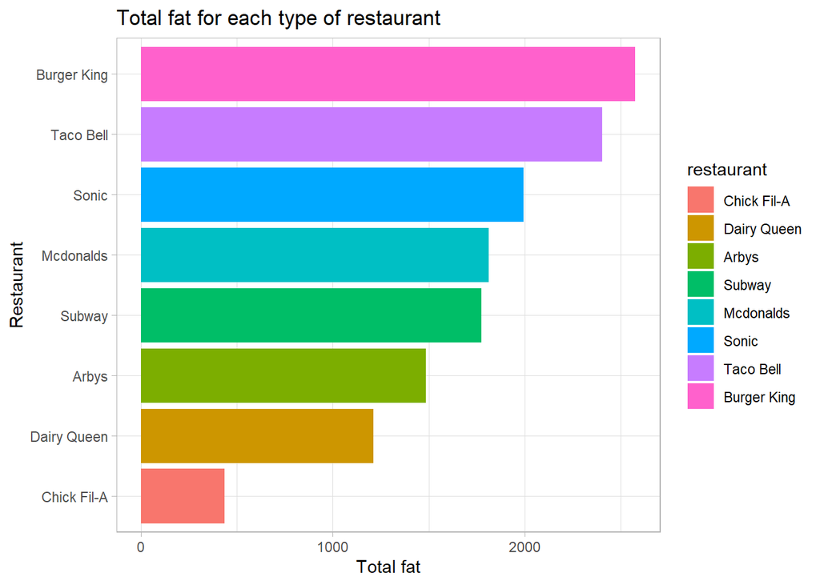

```r
#15 Displaying total fat for each restaurant with data visualization
theme_set(theme_light())
fastfood %>%
mutate(restaurant = fct_reorder(restaurant, total_fat, sum ))%>%
ggplot(aes(x=restaurant,
     y=total_fat, fill=restaurant))+
  geom_col()+
  coord_flip()+
  labs(x = "Restaurant",
       y = "Total fat",
       title = "Total fat for each type of restaurant")
```

Explanation: From this data visualization we can see total fat for each type of fast food restaurant. We can say Burger King has the highest amount of fat followed by Taco Bell. Chick Fil-A has the least amount of fat and looks like it is better option in terms of fat. Data visualization gives us a clear idea of what the information means by giving it visual context through maps or graphs. This makes the data more natural for the human mind to comprehend and therefore makes it easier to identify trends, patterns, and outliers within large data sets.

```r
#16 Adding max total fat variable to the data set by using function groupby and mutate
fastfood<-fastfood%>%
group_by(restaurant)%>%
mutate(max_total_fat = max(total_fat))%>%
ungroup()
```

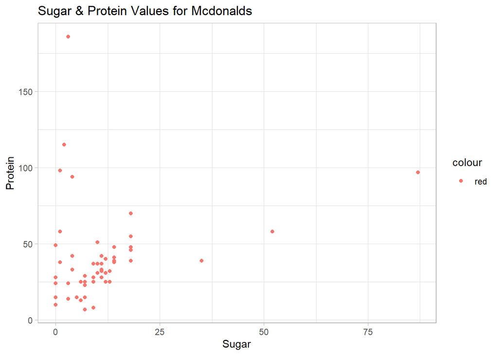

```r
#17 Data visualization of sugar & protein values in Mcdonalds
fastfood%>%
filter(restaurant == "Mcdonalds")%>%
ggplot(aes(x=sugar,
     y=protein,
     color="red"))+
  geom_point()+
  labs(x = "Sugar",
       y = "Protein",
       title = "Sugar & Protein Values for Mcdonalds")
```

Explanation: In this chart we can see the sugar and protein values for Mcdonalds. Most of the sugar values are in between zero and twenty and similarly most of the protein values are in between zero and fifty. There are some outliers as well. This visualization is crucial in terms of showing the density.

#PART 3

```r
#18 Converting variable into a factor
fastfood%>%
mutate(restaurant=as_factor(restaurant))
```

```
## # A tibble: 515 x 20
##        X restaurant item            calories cal_fat total_fat sat_fat trans_fat
##    <int> <fct>      <chr>              <int>   <int>     <int>   <dbl>     <dbl>
##  1     1 Mcdonalds  Artisan Grille~      380      60         7       2       0
##  2     2 Mcdonalds  Single Bacon S~      840     410        45      17       1.5
##  3     3 Mcdonalds  Double Bacon S~     1130     600        67      27       3
##  4     4 Mcdonalds  Grilled Bacon ~      750     280        31      10       0.5
##  5     5 Mcdonalds  Crispy Bacon S~      920     410        45      12       0.5
##  6     6 Mcdonalds  Big Mac              540     250        28      10       1
##  7     7 Mcdonalds  Cheeseburger         300     100        12       5       0.5
##  8     8 Mcdonalds  Classic Chicke~      510     210        24       4       0
##  9     9 Mcdonalds  Double Cheeseb~      430     190        21      11       1
## 10    10 Mcdonalds  Double Quarter~      770     400        45      21       2.5
## # ... with 505 more rows, and 12 more variables: cholesterol <int>,
## #   sodium <int>, total_carb <int>, fiber <int>, sugar <int>, protein <int>,
## #   vit_a <int>, vit_c <int>, calcium <int>, salad <chr>,
## #   average_calories <dbl>, max_total_fat <int>
```

We can convert variables, which we can use them to group by data, into a factor variable. In our case and for now we can convert variable restaurant into a factor variable.

```r
#19 Creating new variable calories type to data set
fastfood<-fastfood%>%
mutate(calories_type=cut_number(calories, n=3, labels=c("low", "med", "high"), ordered_result=TRUE))
```

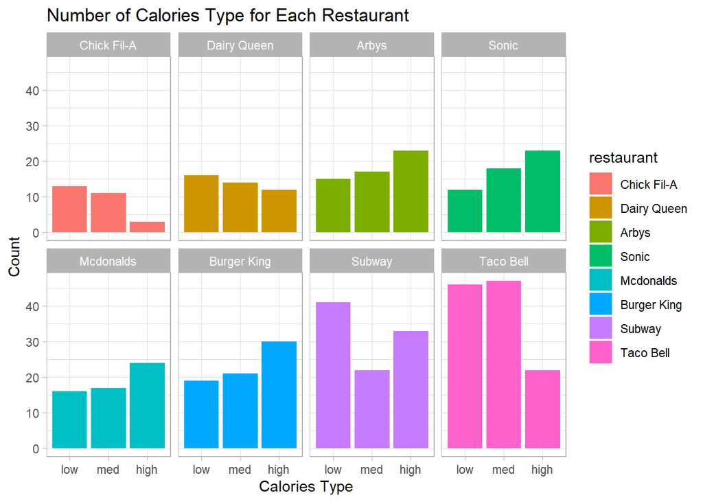

```r
#20 Data Visualization for number of calories type for each restaurant
theme_set(theme_light())
fastfood%>%
  mutate(restaurant = fct_reorder(restaurant, calories, sum))%>%
  ggplot(
 aes(x=calories_type,
     fill=restaurant))+
  geom_bar()+
  labs(x = "Calories Type",
       y = "Count",
       title = "Number of Calories Type for Each Restaurant")+
  facet_wrap(~ restaurant, nrow = 2)
```

Explanation: In this chart we can see the amount of calories type for each restaurant. Taco Bell has the highest amount of calories type counted followed by Subway which is normal these two restaurants have the highest amount of observations. Chick Fil-A has the least amount.

```r
#21 Adding percentage of trans_fat in total_fat
fastfood<-fastfood%>%
mutate(trans_fat_percent=trans_fat/total_fat*100)
```

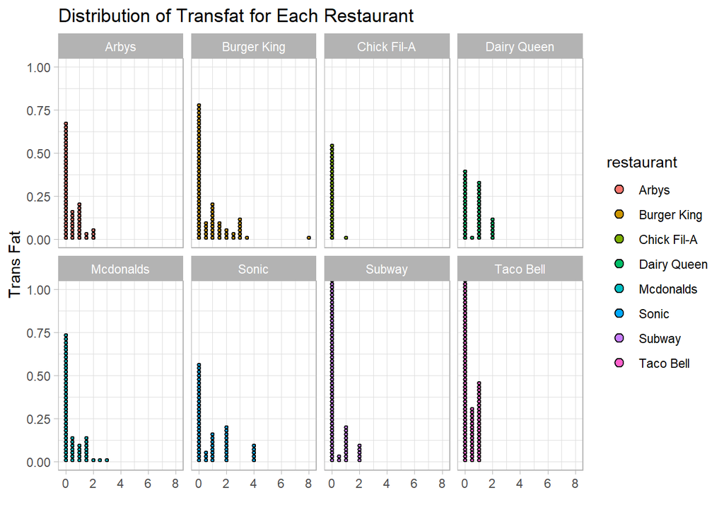

```r
#22 Data Visualization for trans_fat in each restaurant
fastfood%>%
ggplot(aes(trans_fat,
     fill=restaurant))+
  geom_dotplot()+
  labs(x = "",
       y = "Trans Fat",
       title = "Distribution of Transfat for Each Restaurant")+
  facet_wrap(~ restaurant, nrow = 2)
```

```r
#23 Calculating average total fat for each restaurant
fastfood%>%
group_by(restaurant)%>%
summarise(average_total_fat=mean(total_fat))%>%
arrange(desc(average_total_fat))%>%
ungroup()
```

```
## # A tibble: 8 x 2
##   restaurant  average_total_fat
##   <chr>                   <dbl>
## 1 Sonic                    37.6
## 2 Burger King              36.8
## 3 Mcdonalds                31.8
## 4 Dairy Queen              28.9
## 5 Arbys                    27.0
## 6 Taco Bell                20.9
## 7 Subway                   18.5
## 8 Chick Fil-A              16.1
```

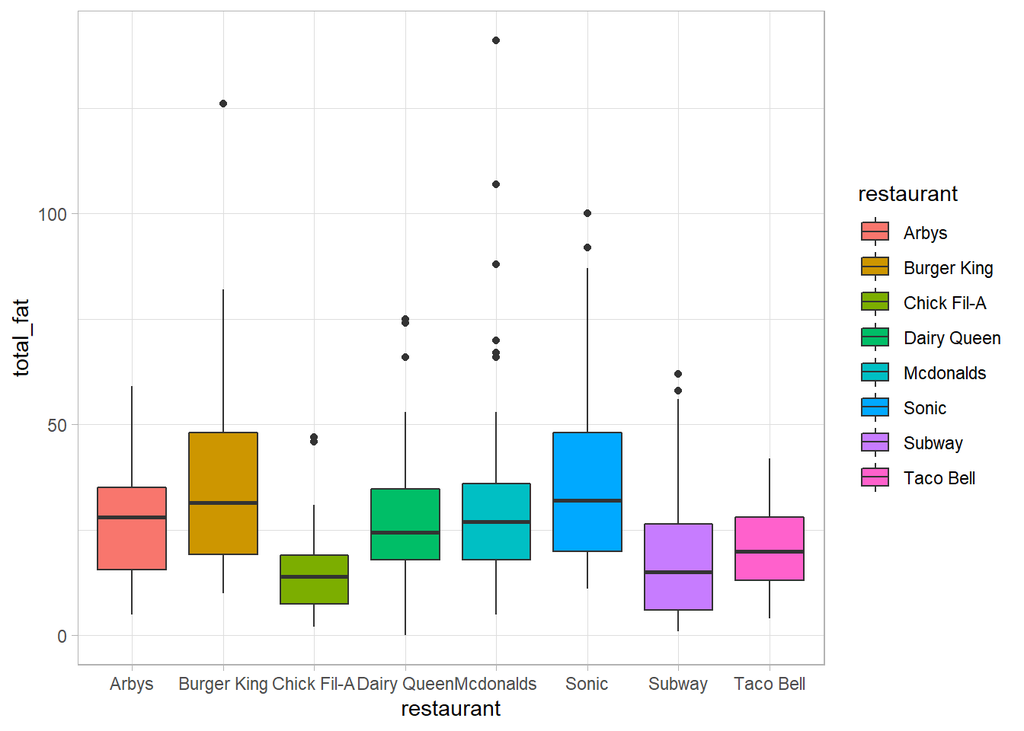

```r
#24 Data visualization to compare restaurants for total fat
fastfood%>%
  ggplot(
 aes(x=restaurant,
     y= total_fat,
     fill=restaurant)
)+
  geom_boxplot()
```

Explanation: In this chart we can see the distribution of total fat for each type of restaurant. There are some outlier for 6 different restaurants. Overall, we can say they are evenly distributed. Burger King and Sonic have highest values and wider distribution.